# A data driven stopping criterion for evolutionary instance selection

September 06, 2016

## Instance selection

**What**

- A pre-processing technique for instance-based classification
- Only "necessary" instances are maintained

**Why**

- Memory
- Prediction time

**How**

- Filters
- Wrappers
  - An evolutionary algorithm with an arbitrary stopping criterion

## Instance-based classification

## Instance-based classification

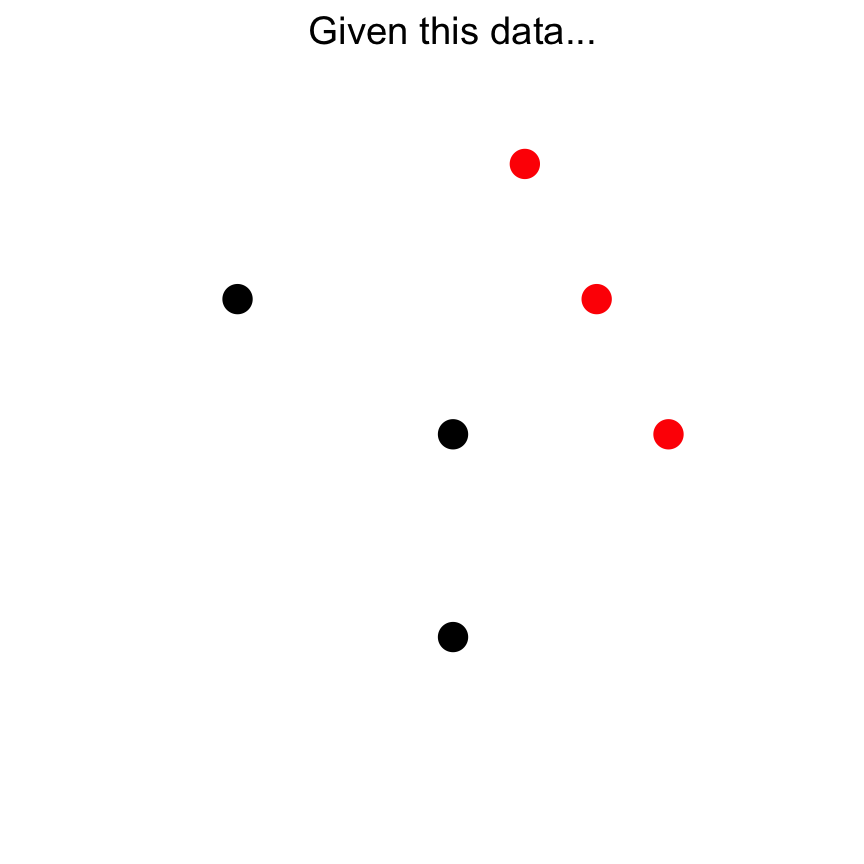

## Instance-based classification

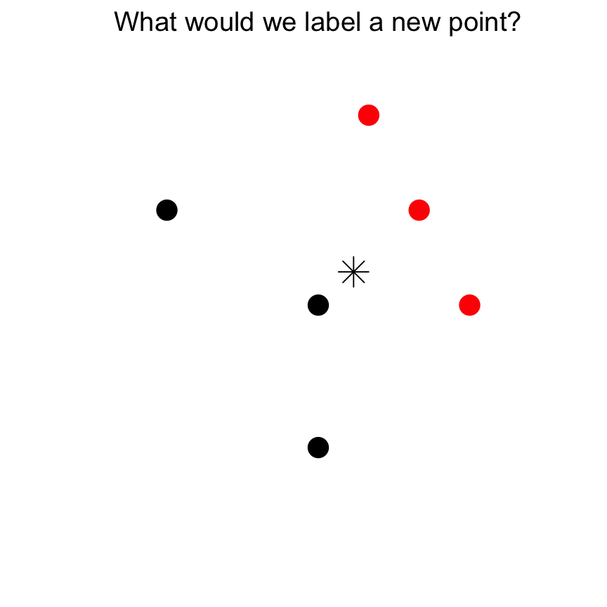

## Instance-based classification

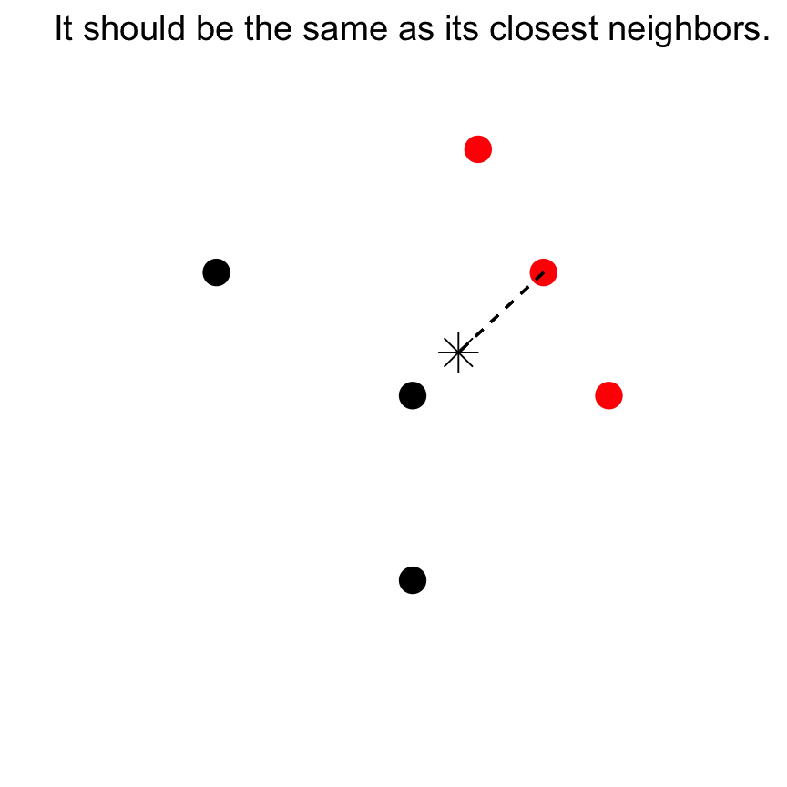

## Instance-based classification

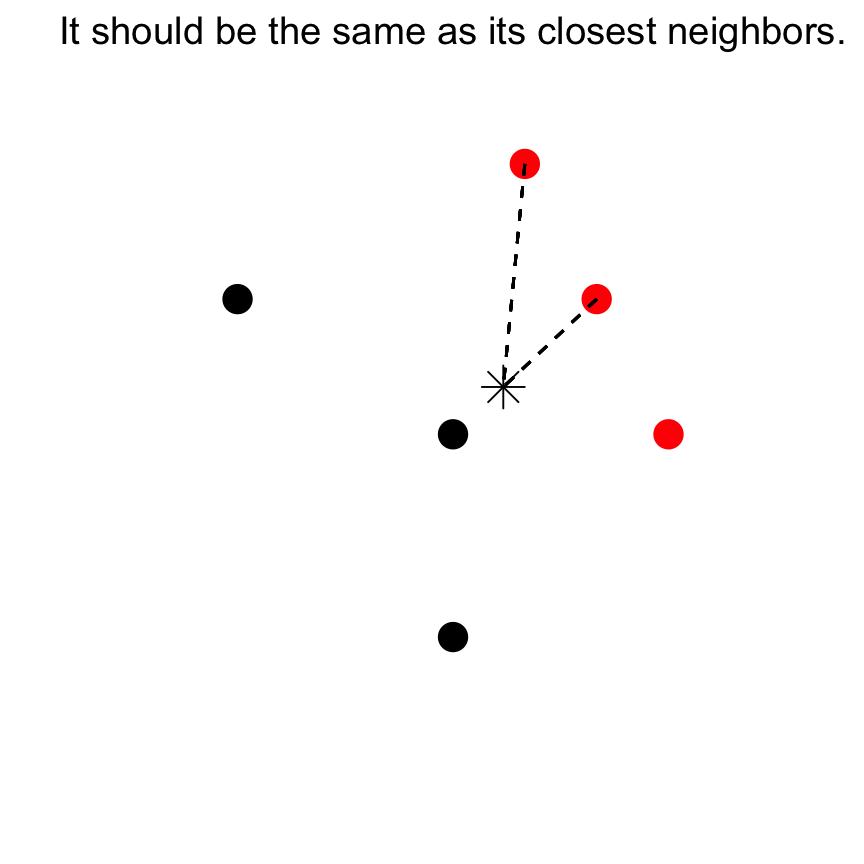

## Instance-based classification

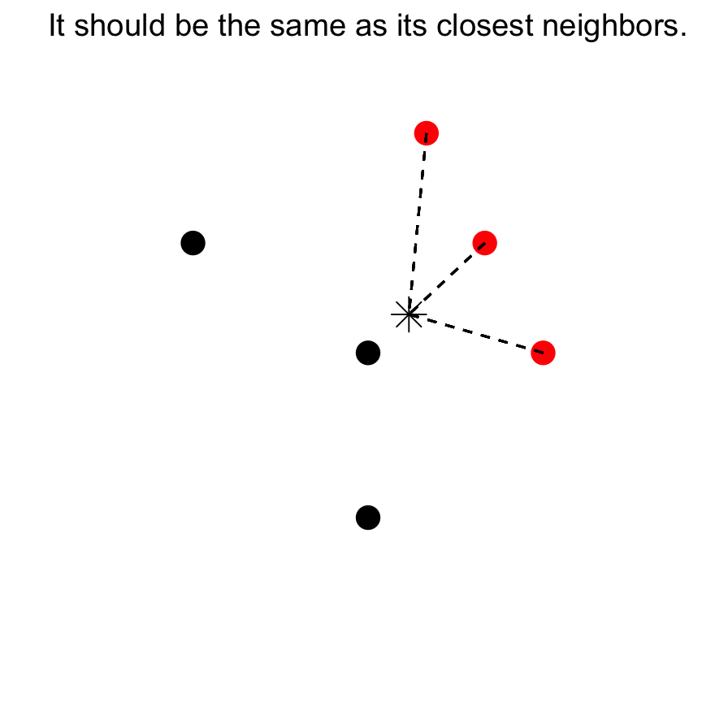

## Instance-based classification

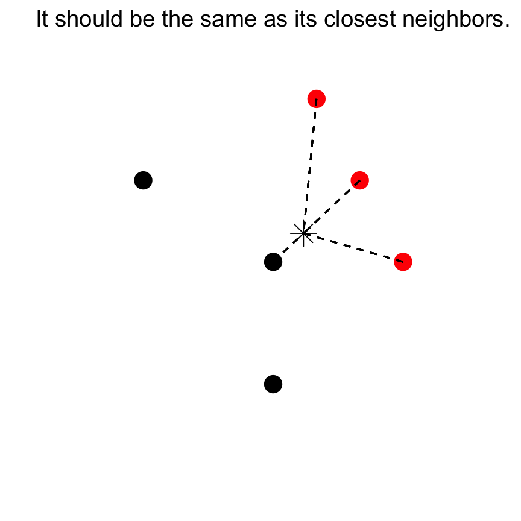

## Instance-based classification

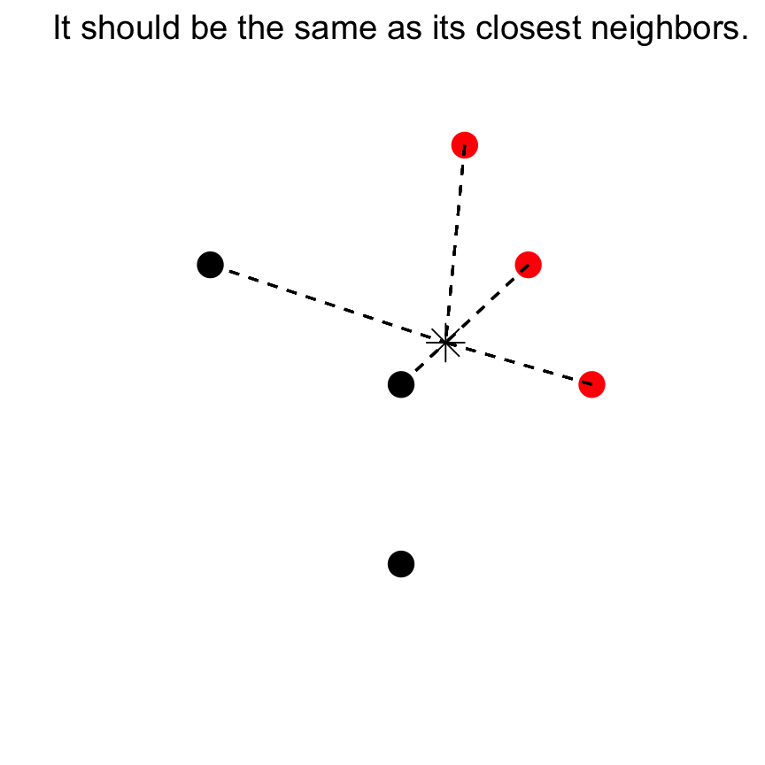

## Instance-based classification

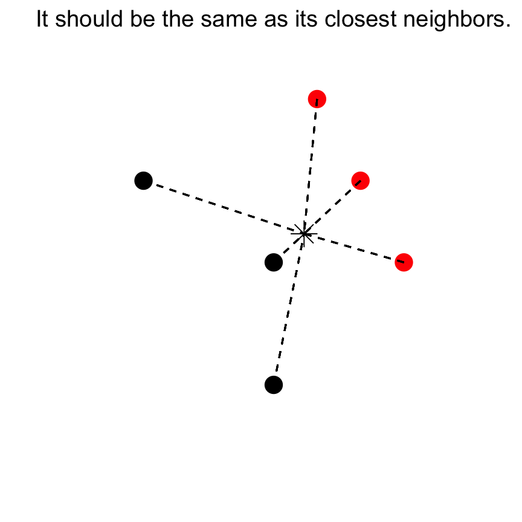

## Instance-based classification

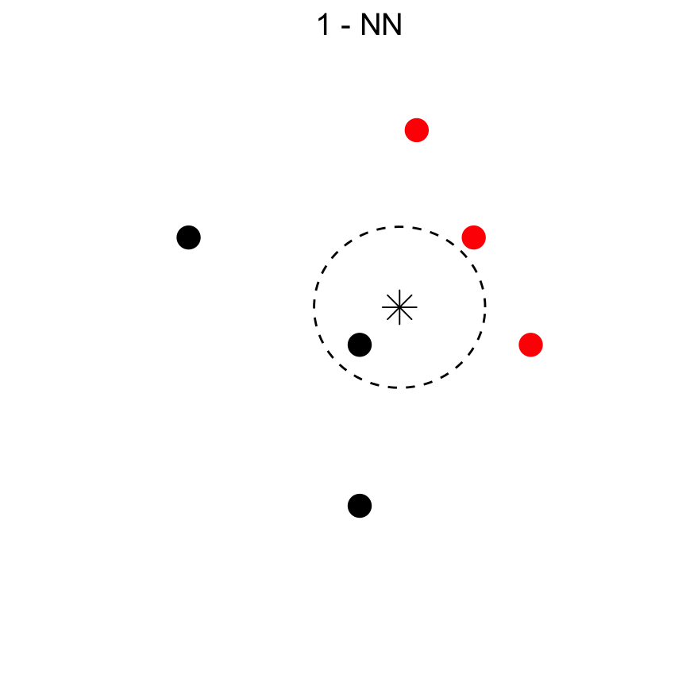

## Instance-based classification

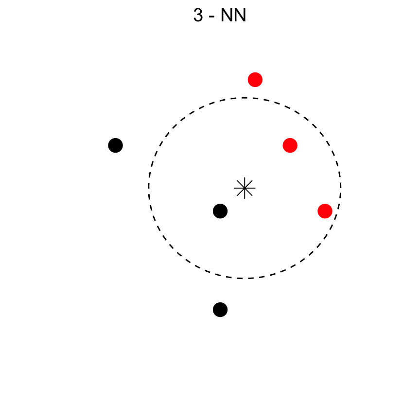

## Instance-based classification

- [Load forecasting assistant for power company](http://ieeexplore.ieee.org/xpl/login.jsp?tp=&arnumber=14540&url=http%3A%2F%2Fieeexplore.ieee.org%2Fiel1%2F59%2F569%2F00014540.pdf%3Farnumber%3D14540)
  - Hourly load forecast
  - Utilize weather and seasonal variables
  - Growing number of data sources and observations
  - Increased control

## Instance-based classification

What if there is a large amount of data?

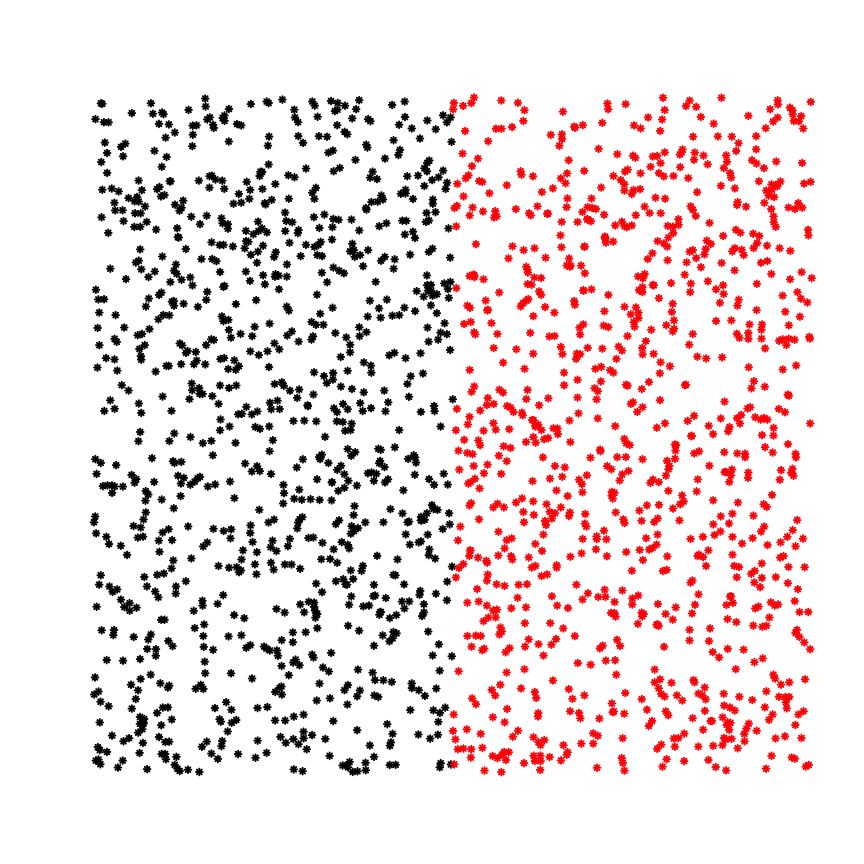

## Instance-based classification

What if there is a huge amount of data?

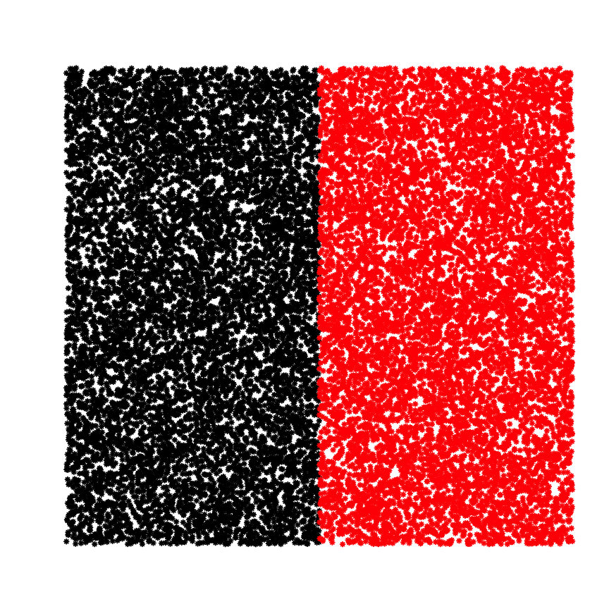

## Instance-based classification

What if there is a serious amount of data?

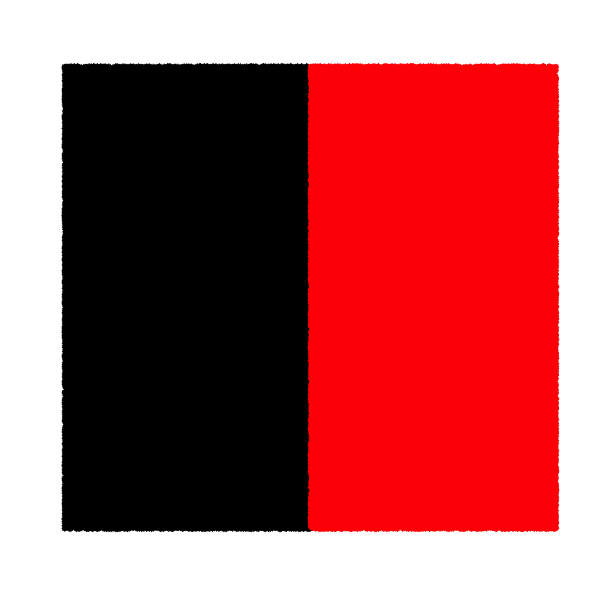

## Instance selection

## Instance selection

**Retain only the instances "necessary" to achieve adequate classification rates**

- Reduce storage requirements
- Reduce prediction time

## Edited Nearest Neighbors (ENN)

Formulation:

- An instance is removed from the training data if its does not agree with the majority of its \(k\) nearest neighbors

Effect:

- Makes decision boundaries smoother
- Doesn't remove much data

## Edited Neares Neighbors (ENN)

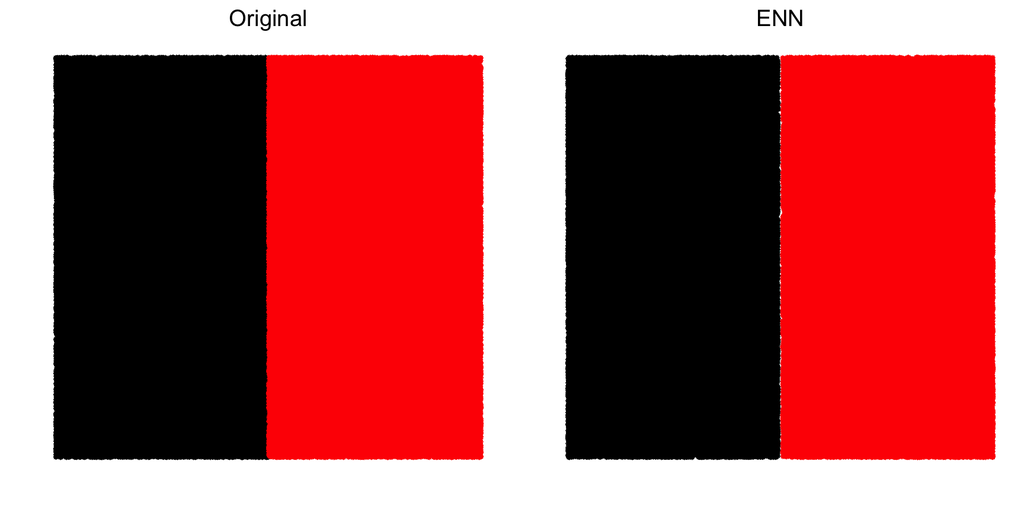

## DROP3

Formulation:

- Iterative procedure that compares accuracy of neighborhoods with and without members

Effect:

- Removes much more data than ENN
- Maintains acceptable accuracy

## DROP3

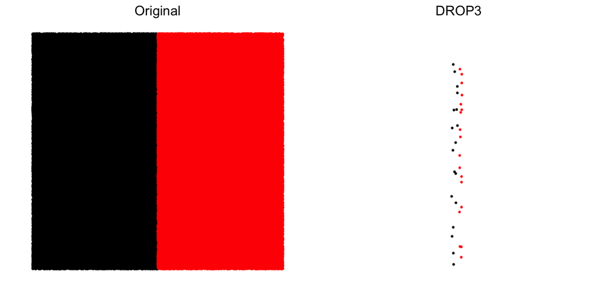

## Evolutionary Instance Selection

## Evolutionary Instance Selection

- Search for best subset of training data
- \(Fitness = \alpha *classAccuracy + (1-\alpha) * percReduction\)
- Each instance is a gene
  - One, keep instance
  - Zero, discard instance

## Evolutionary Instance Selection

- Cano, Herrera, and Lozano (2003), tested families of evolutionary algorithms
- Determined "cross generational elitist selection, heterogeneous recombination and cataclysmic mutation" (CHC) was most effective
- Widely adapted in instance selection literature
- Some of the best results for data reduction and classification accuracy (García, Luengo, and Herrera 2015)

## CHC

1. Create a parent population of size \(N\) and set threshold to \(\frac{|training \ data|}{4}\)
2. Generate a child population from parents
   - Select two previously unconsidered parents
   - If Hamming distance is greater than threshold perform half uniform cross-over (HUX) to generate two children
3. Hold a competition to determine new parent population
   - If no children enter parent population reduce threshold by one
   - If threshold falls below zero perform cataclysmic re-population
     - Reset threshold and discard all chromosomes except most fit
     - Use mutation to generate \(N-1\) new chromosomes
4. Return to Step 2 until stopping criterion is met

## Current CHC stopping critierion

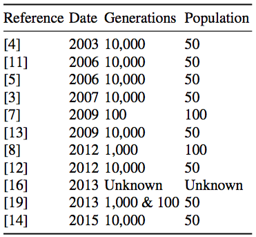

## Data driven CHC stopping critierion

- At a cataclysmic re-population, compare the best individual to the best individual from the last cataclysmic re-population
- If the improvement in fitness is less than or equal to some \(G\), stop

## Data driven example

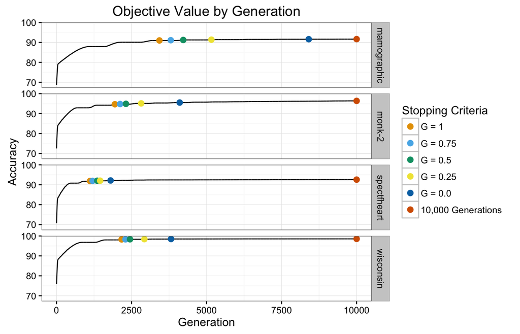

## Data driven example

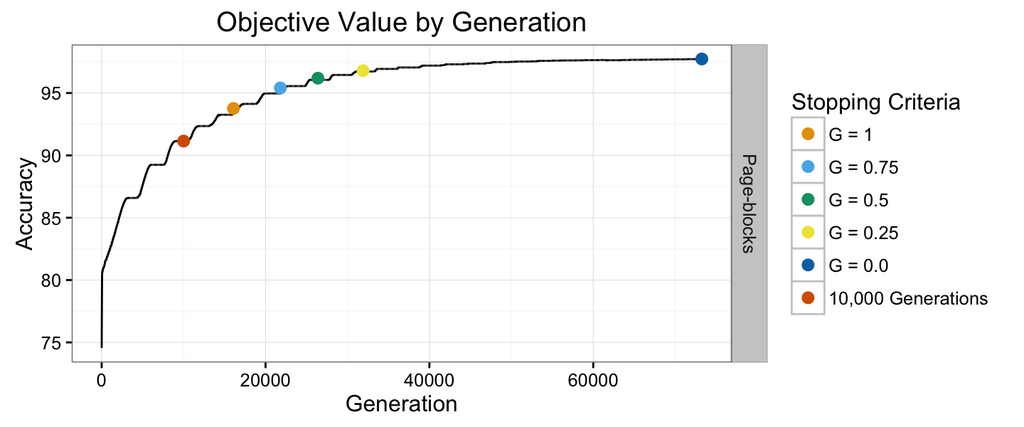

- CHC has difficulty converging when there are many instances
- Most recommend a stratified scaling approach

## Data driven example

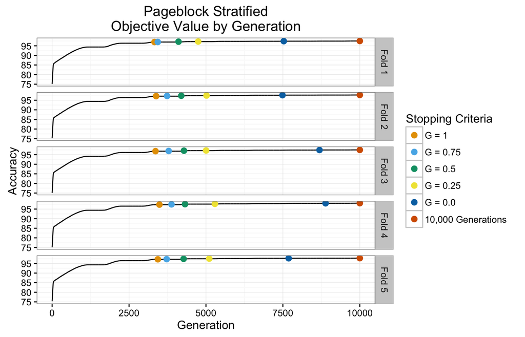

## Experiment

Using 3-NN:

- Compare CHC_10K and CHC_0 (10k generations versus data driven for \(G=0\))
- 10-fold cross validation applied three times
- Record accuracy, reduction, and computation time
- 30 "small" datasets (100 - 1,000 instances)
- 21 "medium" datasets, using stratification (1,001 - 12,960 instances)
- Wilcoxin Signed Ranked test for differences in accuracy, reduction, and time

## Results

| Size | Method | Accuracy | Reduction | Time |
| --- | --- | --- | --- | --- |
| Small | CHC_10K | 77.3 | 91.1 | 119 |
| Small | CHC_0 | 77.3 | 90.6 | 64 |
| Medium | CHC_10K | 75.4 | 90.9 | 1631 |
| Medium | CHC_0 | 75.6 | 90.8 | 1415 |

- No significant difference in accuracy
- Significant (but small) difference in reduction
- Significant difference in time

## Unexpected results

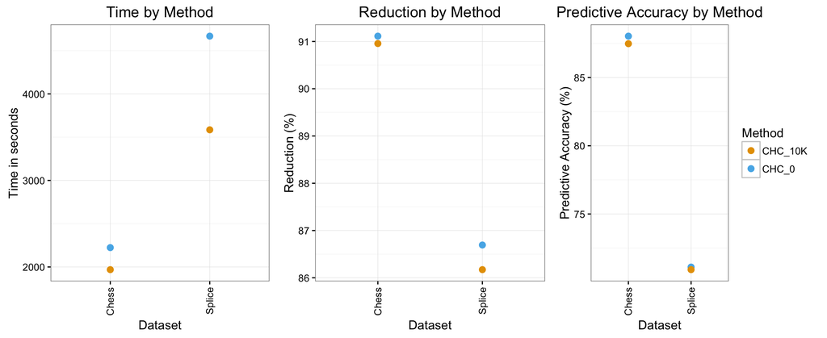

## Take away one

- A set number of generations is not the correct way to terminate CHC
- CHC_0 is a criterion
- Additional criterion can be created

## A word on the competittion

| Size | Method | Accuracy | Reduction | Time |
| --- | --- | --- | --- | --- |
| Small | 3-NN | 78.6 | NA | NA |
| Small | DROP3 | 76.1 | 90.7 | 1 |
| Small | CHC_0 | 77.3 | 90.6 | 64 |
| Medium | 3-NN | 78.7 | NA | NA |
| Medium | DROP3 | 73.7 | 92.8 | 17 |
| Medium | CHC_0 | 75.6 | 90.8 | 1415 |

- On average, DROP3 achieves greater reduction
- On average, CHC_0 achieves better accuracy
- DROP3 is very fast

## Take away two

- Practitioners need to keep their application in mind
- Use DROP3 when instance selection needs to be applied quickly
- Use CHC when accuracy is a priority

## Questions

Walter Bennette  
walter.bennette.1@us.af.mil  
wdbennette@gmail.com

## References

Cano, J.R., F. Herrera, and M. Lozano. 2003. “Using evolutionary algorithms as instance selection for data reduction in KDD: an experimental study.” *IEEE Transactions on Evolutionary Computation* 7 (6): 561–75.

García, Salvador, Julian Luengo, and Francisco Herrera. 2015. *Data Preprocessing in Data Mining*. Vol. 72. Intelligent Systems Reference Library. Cham: Springer International Publishing. http://link.springer.com/10.1007/978-3-319-10247-4 http://www.scopus.com/inward/record.url?eid=2-s2.0-84906871736{\&}partnerID=tZOtx3y1.